# Homework #7

5A.Let’s start with the Palmer Penguins data. Let’s look at just the Gentoo. Why don’t you plot the distribution of the average flipper length of females. We’ll use this data for the exercise. Remember to remove NAs - it will make the rest of the exercise easier. 1 EC for each thing you do to snaz the plot up.

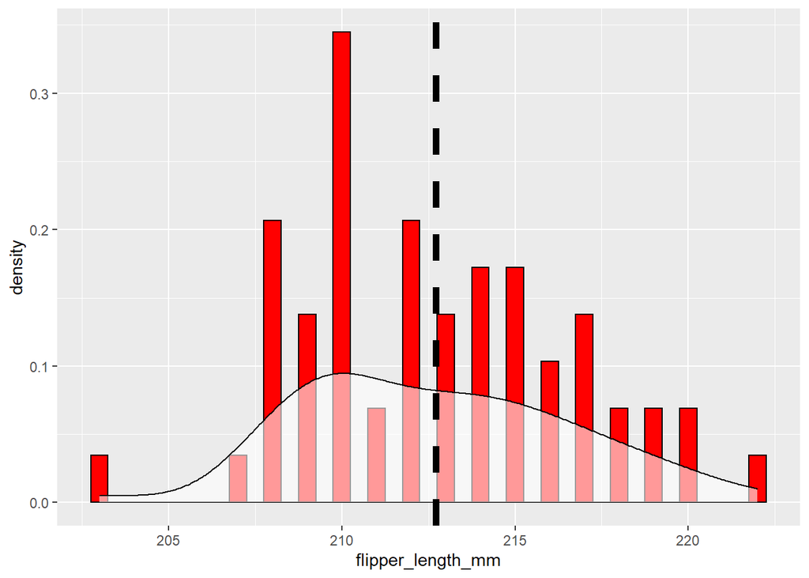

```r
#loading penguins data
library(palmerpenguins)

#taking out the NAs of the penguin dataset
penguins_no_na <- na.omit(penguins)

#Filtering just Gentoo penguins in the dataset
peng_gentoo <- penguins_no_na %>%
  filter(species == "Gentoo")

#filtering just females in the Gentoo penguins dataseet
peng_gentoo_females <- peng_gentoo %>%
  filter(sex == "female")


#using ggplot to plot a histogram showing female flipper length
ggplot(peng_gentoo_females,
       mapping=aes(x=flipper_length_mm)) + geom_histogram(aes(y=..density..),
#Histogram with density instead of count on y-axis
                   binwidth=.5,
                   colour="black", fill="red") +
    geom_density(alpha=.6, fill="#FFFFFF") +
# Overlay with transparent density plot

   geom_vline(aes(xintercept=mean(flipper_length_mm)), color="black", linetype="dashed", size=2)
```

```r
#Adding a line to show the mean of flipper length

mean(peng_gentoo_females$flipper_length_mm)
```

```
## [1] 212.7069
```

```r
#the mean flipper length for females is 212.7069

sd(peng_gentoo_females$flipper_length_mm)
```

```
## [1] 3.897856
```

```r
#standard deviation of flipper length for females is 3.897856
```

5B. OK, this is pretty normal, with a mean of 212.71 and sd of 3.9. Make a grid to search a number of values around that mean and SD, just as you did for likelihood. Let’s say 100 values of each parameter.

```r
#making a grid using crossing and estimating my mean with values of 210-215, and estimating my sd with values of 3-4 each with a length of 100 to yield 10,000 rows
peng_grid_samp <- crossing(mean = seq(210,215, length.out = 100),
                      sd = seq(3,4, length.out = 100))

peng_grid_samp
```

```
## # A tibble: 10,000 x 2
##     mean    sd
##    <dbl> <dbl>
##  1   210  3
##  2   210  3.01
##  3   210  3.02
##  4   210  3.03
##  5   210  3.04
##  6   210  3.05
##  7   210  3.06
##  8   210  3.07
##  9   210  3.08
## 10   210  3.09
## # ... with 9,990 more rows
```

5C. Write a function that will give you the numerator for any combination of m and s! This is just the same as writing a function for likelihood, but including an additional multiplier of p(H), when putting in the likelihood. Let’s assume a prior for m of dnorm(210, 50) and for s of dunif(1,10) - so, pretty weak!

So, we want p(m, s|flipper length)*p(m)*p(s).

BUT - small problem. These numbers get so vanishingly small, we can no longer do calculations with them. So, for any probability density you use, add log=TRUE and take a sum instead of products or multiplication, as

log(p(D|H)p(H))=log(p(D|H))+log(p(H))

```r
#function to find numerator every time
num_funct <- function(m, s){

sum(dnorm(peng_gentoo_females$flipper_length_mm, m, s, log = TRUE)) +
    #adding our priors
    dnorm(m, 210, 50, log = TRUE) +
    #adding standard deviation
    dunif(s, 1,10, log = TRUE)


}

?dunif
```

5D. Great! Now use this function with your sample grid to get the numerator of the posterior, and then standardize with the p(D) - the sum of all numerators - to get a full posterior. Note, as we’re working in logs, we just subtract log(p(D)) What is the modal estimate of each parameter? How do they compare to the standard frequentist estimate?

Note: log(p(d)) = log(sum(exp(p(D|H)p(H))))

```r
#going rowwise by mean and sd
peng_grid_samp <- peng_grid_samp %>%
  rowwise(mean,sd) %>%

  #creating a new column to show numerator using our function
  mutate(numerator = num_funct(m=mean, s=sd))


peng_log_post <- log(sum(exp(peng_grid_samp$numerator)))


#caluclating posterior for each row
peng_grid_samp <- peng_grid_samp %>%
  rowwise() %>%
  #adding a log posterior and posterior column
  #
  mutate(log_posterior = numerator - peng_log_post,

         #caluclating posterior by taking the exponential of the log posterior
         posterior = exp(log_posterior))
```

6 FINAL PROJECT We’re at the half-way point in the course, and after the mid-term, it’s time to start thinking about your final project. So…. I want to know a bit about what you’re thinking of!

6A. What is the dataset you are thinking of working with? Tell me a bit about what’s in it, and where it comes from.

```r
#For my thesis, I'm planning on analyzing Sphingidae occurrence datasets from North America. I'm not sure which dataset that I want to look at specifically for this project but I've compiled a list of 8 datasets so far from iNaturalist, Vermont Center for Ecostudies, MPM Milwaukee Public Museum Invertebrate Zoology Collection, The Lepidopterists' Society, Yale Peabody Museum, Museum of Comparative Zoology - Harvard University and Butterflies and Moths of North America and BugGuide. The datasets contain a mixture of historical specimen records, occurrence data from professionals and sightings recorded by citizen scientists. I've attached a summary table of what each data set contains and from briefly exploring the datasets, I've noticed that a lot of data cleaning is needed. Most of the datasets are missing IDs and record dates for some occurences so I will have to exclude them during my data cleaning process. I will also have to format dates so they will be in usable form(month and year in separate columns) Additionally, I will exclude species that don't have an adequate amount of records from my data analysis. I still have yet to decide what I want my base record amount to be for a species to be included in my data analysis.

#Attached is the summary of all the datasets
summary_of_datasets <- read.csv("Datasets Summary.csv")

summary_of_datasets
```

```
##                                                                          ï..Dataset
## 1                              Records of Hawk Moths (Sphingidae) from Vermont, USA
## 2 â\200œSphingidaeâ\200\235 from MPM Milwaukee Public Museum Invertebrate Zoology Collection
## 3                                        The Lepidopterists' Society Season Summary
## 4                                          Entomology Division, Yale Peabody Museum
## 5                                 Museum of Comparative Zoology, Harvard University
## 6                                                                            BAMONA
## 7                                                                iNat Sphingids USA
## 8                                                                          BugGuide
##                                                                                                                                                                                                                  Citation
## 1 McFarland K, Hanson T (2019). Records of Hawk Moths (Sphingidae) from Vermont, USA. Version 1.4. Vermont Center for Ecostudies. Occurrence dataset https://doi.org/10.15468/eiiruj accessed via GBIF.org on 2020-10-27.
## 2              Colby J (2019). MPM Milwaukee Public Museum Invertebrate Zoology Collection. Version 1.7. Milwaukee Public Museum. Occurrence dataset https://doi.org/10.15468/d1zyd0 accessed via GBIF.org on 2020-10-27.
## 3                                  The Lepidopterists' Society Season Summary (2019). The Lepidopterists' Society Season Summary. Occurrence dataset https://doi.org/10.15468/jo1wfa accessed via GBIF.org on 2020-10-27.
## 4                                                                                                                                  GBIF.org (27 October 2020) GBIF Occurrence Download https://doi.org/10.15468/dl.tg3zmu
## 5                                                                                                                                                                                        https://mczbase.mcz.harvard.edu/
```

[output cut: 30 more lines]

6B. What question do you want to ask of that data set?

```r
#I want to see if any Sphingidae species have been advancing emergence times in the spring in recent years. There is a good amount of published literature about advancing phenology of Lepidoptera. My first step will be looking to see if I can find a trend in first appearance times over a span of years. I might find a negative trend(earlier emergence times), no trend(no change in emergence times) or postive trend(later emergene times). Then, I plan on comparing emergence time with many different variables to see if there is a correlation. Some example variables that I plan on using are temperature, precipitation, long/lat, etc. I'm curious to see what Sphingidae species are being affected and to see if I can quantify to what extent. I know the life histories of each species plays a role. I also know that my data will dictate what species I can include in my study since I need a certain amount of records for a species to perform data analysis accurately. To my knowledge, no study has specifically looked at Sphingidae phenology in North America. Most of the literature that I've reviewed are studies looking at Lepidoptera penology in Europe, which might yield different results than North America.
```

EC C. Wanna make a quick visualization of some aspect of the data that might be provocative and interesting?

```r
library(ggplot2)

#importing test data of Hemaris diffinis occurrences in the United States from BugGuide spanning from 1981-2019
hemaris_diffinis <-read.csv("Hemaris_BugGuide.csv")

str(hemaris_diffinis)
```

```
## 'data.frame':    494 obs. of  50 variables:
##  $ ï..gbifID                       : num  2.54e+09 2.54e+09 2.54e+09 2.54e+09 2.54e+09 ...
##  $ datasetKey                      : chr  "cca13f2c-0d2c-4c2f-93b9-4446c0cc1629" "cca13f2c-0d2c-4c2f-93b9-4446c0cc1629" "cca13f2c-0d2c-4c2f-93b9-4446c0cc1629" "cca13f2c-0d2c-4c2f-93b9-4446c0cc1629" ...
##  $ occurrenceID                    : int  1555351 1635746 1682691 1492522 1528306 1688523 1719792 1517507 1628719 1542636 ...
##  $ kingdom                         : chr  "Animalia" "Animalia" "Animalia" "Animalia" ...
##  $ phylum                          : chr  "Arthropoda" "Arthropoda" "Arthropoda" "Arthropoda" ...
##  $ class                           : chr  "Insecta" "Insecta" "Insecta" "Insecta" ...
##  $ order                           : chr  "Lepidoptera" "Lepidoptera" "Lepidoptera" "Lepidoptera" ...
##  $ family                          : chr  "Sphingidae" "Sphingidae" "Sphingidae" "Sphingidae" ...
##  $ genus                           : chr  "Hemaris" "Hemaris" "Hemaris" "Hemaris" ...
##  $ species                         : chr  "Hemaris diffinis" "Hemaris diffinis" "Hemaris diffinis" "Hemaris diffinis" ...
##  $ infraspecificEpithet            : logi  NA NA NA NA NA NA ...
##  $ taxonRank                       : chr  "SPECIES" "SPECIES" "SPECIES" "SPECIES" ...
##  $ scientificName                  : chr  "Hemaris diffinis Boisduval, 1836" "Hemaris diffinis Boisduval, 1836" "Hemaris diffinis Boisduval, 1836" "Hemaris diffinis Boisduval, 1836" ...
##  $ verbatimScientificName          : chr  "Hemaris diffinis" "Hemaris diffinis" "Hemaris diffinis" "Hemaris diffinis" ...
```

[output cut: 36 more lines]

```r
min(hemaris_diffinis$year)
```

```
## [1] 1981
```

```r
max(hemaris_diffinis$year)
```

```
## [1] 2019
```

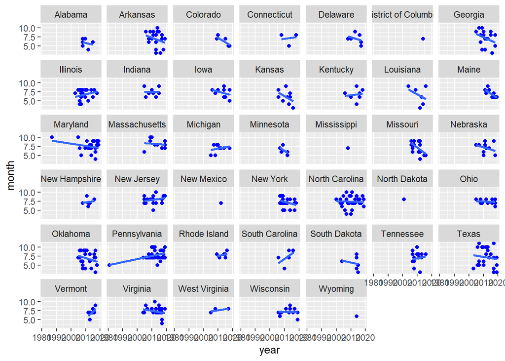

```r
ggplot(hemaris_diffinis,
       aes(x = year, y = month)) +
  geom_point(color='blue') +
  geom_smooth(method = "lm", se = FALSE)+
  facet_wrap(~stateProvince)
```

```r
#The plot that I show here depicts year on x axis and month on y axis and each plot represents a different state. This plot provides good visualization to see in which states data is lacking. Some states have ample data points and other have only one or two data points. I've included a line of best fit in each plot to see if the sightings have advanced earlier as the years have gone by. The plots are clearly displaying a mix of positive, negative and neutral slopes. The next step would be to compare a variable, like temperature, for each state over the years, to see if that slope matches the slopes of appearance dates. The variation in the slopes might be caused by sampling effort differences in each state, observer bias, the region that each state is located in, or many other factors. I will have to account for bias in my data analysis.
```

My github homework link is here: https://github.com/Jbarrone95/Biol-607-Homework-